# AED R and Friends: Basic Statistics with R

# Introduction

This notebook will cover calculating basic statistics with R, conducting statistical tests, and building simple linear models. We will use the 2007 NLA data for the examples and show steps from getting data, to cleaning data, to analysis and statistics.

## Get Data

First step in any project will be getting the data read into R. For this lesson we are using the 2007 National Lakes Assessment data, which ,luckily, can be accessed directly from a URL.

```r
# URL for 2007 NLA water quality data
nla_wq_url <- "https://www.epa.gov/sites/production/files/2014-10/nla2007_chemical_conditionestimates_20091123.csv"
nla_secchi_url <- "https://www.epa.gov/sites/production/files/2014-10/nla2007_secchi_20091008.csv"
# Read into an R data.frame with read.csv
nla_wq <- read.csv(nla_url, stringsAsFactors = FALSE)
nla_secchi <- read.csv(nla_secchi_url, stringsAsFactor = FALSE)
```

## Clean Data

So this is a bit bigger, let’s do some clean up on this dataset, using `dplyr`. We want to select out a few columns, filter out the data that we want and get our data.frame ready for futher analysis.

```r
#Load dplyr into current session
library(dplyr)
#Clean up NLA Water quality
nla_wq_cln <- nla_wq %>%
  filter(VISIT_NO == 1,
         SITE_TYPE == "PROB_Lake") %>%
  select(SITE_ID,ST,EPA_REG,RT_NLA,PTL,NTL,TURB,CHLA)
#Clean up NLA Secchi
nla_secchi_cln <- nla_secchi %>%
  filter(VISIT_NO == 1) %>%
  select(SITE_ID, SECMEAN)
#Join the two together based on SITE_ID and the finally filter out NA's
nla <- left_join(x = nla_wq_cln, y = nla_secchi_cln, by = "SITE_ID") %>%
  filter(complete.cases(NTL,PTL,TURB,CHLA,SECMEAN))
tbl_df(nla)
```

```
Source: local data frame [974 x 9]

         SITE_ID    ST  EPA_REG RT_NLA   PTL   NTL   TURB  CHLA SECMEAN
           <chr> <chr>    <chr>  <chr> <int> <int>  <dbl> <dbl>   <dbl>
1  NLA06608-0001    MT Region_8    REF     6   151  0.474  0.24    6.40
2  NLA06608-0002    SC Region_4  SO-SO    36   695  3.550  3.84    0.55
3  NLA06608-0003    TX Region_6  TRASH    43   738  7.670 16.96    0.71
4  NLA06608-0004    CO Region_8  SO-SO    18   344  3.810  4.60    1.80
5  NLA06608-0006    CT Region_1    REF     7   184  0.901  4.08    3.21
6  NLA06608-0007    WI Region_5    REF     8   493  1.050  2.43    3.15
7  NLA06608-0008    IA Region_7  SO-SO    66   801  8.620 30.24    0.79
8  NLA06608-0010    MI Region_5  SO-SO    10   473  3.050  4.38    4.48
9  NLA06608-0012    OK Region_6  TRASH   159  1026 50.300  4.90    0.31
10 NLA06608-0013    NJ Region_2  SO-SO    28   384  4.210 16.03    0.65
..           ...   ...      ...    ...   ...   ...    ...   ...     ...
```

So now we have a dataset ready for analysis.

## Analyze Data

### Basic Stats

First step in analyzing a dataset like this is going to be to dig through some basic statistics as well as some basic plots.

We can get a summary of the full data frame:

```r
#Get a summary of the data frame
summary(nla)
```

```
   SITE_ID               ST              EPA_REG
 Length:974         Length:974         Length:974
 Class :character   Class :character   Class :character
 Mode  :character   Mode  :character   Mode  :character



    RT_NLA               PTL              NTL               TURB
 Length:974         Min.   :   1.0   Min.   :    5.0   Min.   :  0.237
 Class :character   1st Qu.:  11.0   1st Qu.:  329.5   1st Qu.:  1.643
 Mode  :character   Median :  30.0   Median :  603.5   Median :  4.145
                    Mean   : 114.1   Mean   : 1190.5   Mean   : 14.133
                    3rd Qu.: 100.0   3rd Qu.: 1214.2   3rd Qu.: 11.675
                    Max.   :4679.0   Max.   :26100.0   Max.   :574.000
      CHLA            SECMEAN
 Min.   :  0.070   Min.   : 0.0400
 1st Qu.:  3.163   1st Qu.: 0.6125
 Median :  8.670   Median : 1.3000
 Mean   : 30.884   Mean   : 2.0759
 3rd Qu.: 27.492   3rd Qu.: 2.7475
 Max.   :936.000   Max.   :36.7100
```

Or, we can pick and choose what stats we want. For instance:

```r
#Stats for Total Nitrogen
mean(nla$NTL)
```

```
[1] 1190.468
```

```r
median(nla$NTL)
```

```
[1] 603.5
```

```r
min(nla$NTL)
```

```
[1] 5
```

```r
max(nla$NTL)
```

```
[1] 26100
```

```r
sd(nla$NTL)
```

```
[1] 2122.182
```

```r
IQR(nla$NTL)
```

```
[1] 884.75
```

```r
range(nla$NTL)
```

```
[1]     5 26100
```

In these cases we took care of our NA values during our data clean up, but there may be reasons you would not want to do that. If you retained NA values, you would need to think about how to handle those. One way is to remove it from the calculation of the statistics using the `na.rm = TRUE` argument. For instance:

```r
#An example with NA's
x <- c(37,22,NA,41,19)
mean(x) #Returns NA
```

```
[1] NA
```

```r
mean(x, na.rm = TRUE) #Returns mean of 37, 22, 41, and 19
```

```
[1] 29.75
```

### Some quick useful viz

We can look at histograms:

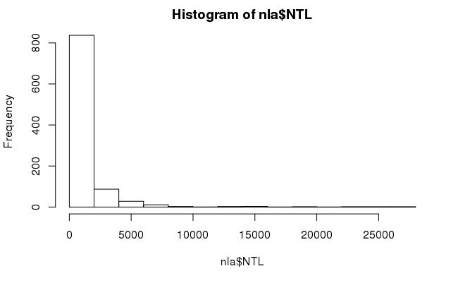

```r
#A single histogram using base
hist(nla$NTL)
#Log transform it
hist(log1p(nla$NTL)) #log1p adds one to deal with zeros
```

[figure not shown]

```r
#Density plot
plot(density(log1p(nla$NTL)))
```

[figure not shown]

[figure not shown]

```r
#Getting fancy with tidyr and ggplot2 to visualize all variables
library(tidyr)
library(ggplot2)
nla_gather <- gather(nla,parameter,value,5:9)
ggplot(nla_gather,aes(x=log1p(value))) +
  geom_density() +
  facet_wrap("parameter") +
  labs(x="log1p of measured value")
```